# Estratificación socioeconómica municipal por cuadrante (cuadrantes reales)

Cindy Carolina Lugo Rozo

2026-09-07

# Introducción

Este documento continúa el pipeline de construcción del panel **semana x cuadrante** para SAIDI/SAIFI, retomando exactamente donde quedó el documento de infraestructura + NDVI (`cuadrantes_infra`, `data_final` y el `.gpkg` ya exportado con esas capas).

**Objetivo de este documento:** incorporar información oficial de **estratificación socioeconómica**, como variable de control adicional (hipótesis: redes en municipios de estrato bajo suelen ser más antiguas, con menor mantenimiento preventivo, lo que se asocia con mayor frecuencia y duración de interrupciones).

**Precisión metodológica importante, que se mantiene durante todo el documento:** la fuente disponible (`Estr_Capa.gdb`, capa `Mpio_Metodologia_Estr_Estr_Predom`) reporta el **estrato predominante a nivel municipal**, no a nivel de vivienda o predio dentro del cuadrante. Por eso la variable se nombra explícitamente `estrato_predominante_municipal` en vez de `estrato_cuadrante`: la primera es la afirmación que los datos realmente soportan; la segunda implicaría una precisión espacial que no se tiene (sería el paralelo municipal de la variable `estrato_modal` calculada previamente con el shapefile catastral predial, cuando ese sí estaba disponible a nivel de predio).

## Paquetes y carga de insumos previos

```r
options(repos = c(CRAN = "https://cloud.r-project.org"))

paquetes_estrato <- c("sf", "dplyr", "readr", "ggplot2", "knitr",
                      "kableExtra", "scales", "leaflet", "htmlwidgets")

invisible(lapply(paquetes_estrato, function(p) {
  if (!requireNamespace(p, quietly = TRUE)) install.packages(p)
  library(p, character.only = TRUE)
}))
```

```r
# Misma logica que Scripts/Edwin/analisis_correlacion.Rmd.
# Este Rmd vive en Scripts/Cindy/v4/ → el .env de la raiz esta 3 niveles arriba.
env_path <- file.path("..", "..", "..", ".env")
if (file.exists(".env")) {
  readRenviron(".env")
} else if (file.exists(env_path)) {
  readRenviron(env_path)
}

UBICACION_DATA <- Sys.getenv("UBICACION_DATA")
if (UBICACION_DATA == "") {
  stop("UBICACION_DATA no esta definida. Verifica el archivo .env.")
}

cat(sprintf("UBICACION_DATA: %s\n", UBICACION_DATA))
```

```
## UBICACION_DATA: D:/OneDrive - PUJ Cali/Projecto_Grado_Javeriana/Data_Project/
```

```r
DIR_IMAGENES <- file.path(
  UBICACION_DATA, "imagenes", "estratificacion_municipal_cuadrantes_reales"
)
dir.create(DIR_IMAGENES, recursive = TRUE, showWarnings = FALSE)
knitr::opts_chunk$set(
  fig.path = paste0(DIR_IMAGENES, "/"),
  dev = "png"
)
```

Si vienes de continuar la sesión anterior, `cuadrantes_infra` y `data_final` ya existen en el entorno. Si es una sesión nueva, se recargan desde las exportaciones previas.

```r
ruta_gpkg_export <- file.path(UBICACION_DATA, "infraestructura_cuadrantes_reales.gpkg")

if (!exists("cuadrantes_infra")) {
  cuadrantes_infra <- st_read(ruta_gpkg_export, layer = "cuadrantes_infra_reales", quiet = TRUE)
  cat("cuadrantes_infra recargado desde el .gpkg exportado.\n")
}
```

```
## cuadrantes_infra recargado desde el .gpkg exportado.
```

```r
if (!exists("data_final")) {
  data_final <- readRDS(file.path(UBICACION_DATA, "data_final_modelo_cuadrantes_reales.rds"))
  cat("data_final recargado desde el .rds exportado.\n")
}
```

```
## data_final recargado desde el .rds exportado.
```

```r
cuadrantes_infra <- cuadrantes_infra %>%
  mutate(id_cuadrante = as.character(if ("id_cuadrante" %in% names(.)) id_cuadrante else CUADRANTE))

data_final <- data_final %>%
  mutate(id_cuadrante = as.character(id_cuadrante))

cat(sprintf("cuadrantes_infra: %d polígonos | data_final: %d filas, %d cuadrantes únicos\n",
            nrow(cuadrantes_infra), nrow(data_final), n_distinct(data_final$id_cuadrante)))
```

```
## cuadrantes_infra: 344 polígonos | data_final: 36120 filas, 344 cuadrantes únicos
```

# Parte 1 — Inspección de la File Geodatabase de estratificación

## Descompresión y localización de la geodatabase

La fuente es una **File Geodatabase (`.gdb`)** empaquetada en `.zip`, descargada del portal oficial de estratificación. Se descomprime una sola vez; si la carpeta ya existe, no se repite el proceso.

```r
archivo_zip <- file.path(UBICACION_DATA, "Estr_Capa.gdb.zip")
carpeta_gdb <- file.path(UBICACION_DATA, "estratificacion")

if (!file.exists(archivo_zip)) {
  stop("No se encontró el archivo: ", archivo_zip,
       "\nVerifica que esté en Downloads con ese nombre exacto.")
}

if (!dir.exists(carpeta_gdb)) {
  dir.create(carpeta_gdb, recursive = TRUE)
  unzip(archivo_zip, exdir = carpeta_gdb)
  cat("Geodatabase descomprimida en:", carpeta_gdb, "\n")
} else {
  cat("Carpeta de estratificación ya existe; no se vuelve a descomprimir.\n")
}
```

```
## Geodatabase descomprimida en: D:/OneDrive - PUJ Cali/Projecto_Grado_Javeriana/Data_Project//estratificacion
```

```r
# Localizar la carpeta .gdb dentro de lo descomprimido
gdb <- list.dirs(carpeta_gdb, recursive = TRUE, full.names = TRUE) |>
  grep("\\.gdb$", x = _, value = TRUE)

if (length(gdb) == 0) {
  stop("No se encontró ninguna carpeta .gdb dentro de ", carpeta_gdb)
}

cat("Geodatabase localizada en:", gdb, "\n")
```

```
## Geodatabase localizada en: D:/OneDrive - PUJ Cali/Projecto_Grado_Javeriana/Data_Project//estratificacion/Estr_Capa.gdb
```

## Inventario de capas disponibles

```r
capas_estr <- st_layers(gdb)
capas_estr
```

```
## Driver: OpenFileGDB
## Available layers:
##                          layer_name geometry_type features fields
## 1 Mpio_Metodologia_Estr_Estr_Predom Multi Polygon     1121     11
## 2                  Mpio_VocProd_Rur Multi Polygon     1121      9
##                   crs_name
## 1 WGS 84 / Pseudo-Mercator
## 2 WGS 84 / Pseudo-Mercator
```

# Parte 2 — Asignación de estrato predominante a cuadrantes reales

## Estrategia

La capa `Mpio_Metodologia_Estr_Estr_Predom` contiene información oficial de estratificación **a nivel municipal**. Como `cuadrantes_infra` ya tiene la geometría real de los cuadrantes, la asignación se hace por **intersección espacial directa** (cuadrante → municipio), sin necesidad de reconstruir puntos a partir de `latitud`/`longitud`.

```r
estrato_municipal <- st_read(gdb, layer = "Mpio_Metodologia_Estr_Estr_Predom", quiet = TRUE)

cat(sprintf("Municipios en la capa de estratificación: %d\n", nrow(estrato_municipal)))
```

```
## Municipios en la capa de estratificación: 1121
```

```r
cat("Geometrías inválidas antes de reparar:", sum(!st_is_valid(estrato_municipal)), "\n")
```

```
## Geometrías inválidas antes de reparar: 0
```

```r
estrato_municipal <- st_make_valid(estrato_municipal)

cat("Geometrías inválidas después de reparar:", sum(!st_is_valid(estrato_municipal)), "\n")
```

```
## Geometrías inválidas después de reparar: 0
```

```r
# Por seguridad, revisar también cuadrantes_infra (aunque ya la usaste
# en mapas sin problema, confirma que no tenga el mismo defecto)
cat("Geometrías inválidas en cuadrantes_infra:", sum(!st_is_valid(cuadrantes_infra)), "\n")
```

```
## Geometrías inválidas en cuadrantes_infra: 0
```

```r
if (sum(!st_is_valid(cuadrantes_infra)) > 0) {
  cuadrantes_infra <- st_make_valid(cuadrantes_infra)
}
```

## Homologación de sistemas de coordenadas

```r
cat("CRS cuadrantes_infra:\n"); print(st_crs(cuadrantes_infra)$input)
```

```
## CRS cuadrantes_infra:
```

```
## [1] "WGS 84"
```

```r
cat("CRS estrato_municipal:\n"); print(st_crs(estrato_municipal)$input)
```

```
## CRS estrato_municipal:
```

```
## [1] "WGS 84 / Pseudo-Mercator"
```

```r
# Se usa el CRS de los cuadrantes reales como referencia, para no
# introducir distorsión en la geometría que ya usamos en todo el
# pipeline (mapas, exportaciones, NDVI).
estrato_municipal <- estrato_municipal %>%
  st_transform(st_crs(cuadrantes_infra))
```

## Selección de variables relevantes

```r
estrato_municipal <- estrato_municipal %>%
  select(
    DPTO_CCDGO, DPTO_CNMBR,
    MPIO_CCDGO, MPIO_CNMBR, MPIO_CCNCT,
    TipoMetodologia, ProcesoRevisionGral,
    Estratos_Mun, Estrato_Predom
  )

kable(head(st_drop_geometry(estrato_municipal), 5),
      caption = "Vista previa — capa municipal de estratificación") %>%
  kable_styling(bootstrap_options = c("striped", "condensed"), font_size = 9)
```

Vista previa — capa municipal de estratificación

| DPTO_CCDGO | DPTO_CNMBR | MPIO_CCDGO | MPIO_CNMBR | MPIO_CCNCT | TipoMetodologia | ProcesoRevisionGral | Estratos_Mun | Estrato_Predom |
| --- | --- | --- | --- | --- | --- | --- | --- | --- |
| 25 | CUNDINAMARCA | 777 | SUPATÁ | 25777 | Tipo 2 | Autorizado | 2 | 2 |
| 25 | CUNDINAMARCA | 815 | TOCAIMA | 25815 | Tipo 2 | En proceso | 4 | 2 |
| 25 | CUNDINAMARCA | 772 | SUESCA | 25772 | Metodología DANE | Adoptado | 4 | 2 |
| 25 | CUNDINAMARCA | 807 | TIBIRITA | 25807 | Tipo 3 | No se encuentra en proceso de revisión general | 3 | 2 |
| 25 | CUNDINAMARCA | 862 | VERGARA | 25862 | Tipo 2 | No se encuentra en proceso de revisión general | 2 | 2 |

## Asignación espacial: cuadrante → municipio

```r
cuadrantes_infra_estrato <- st_join(
  cuadrantes_infra,
  estrato_municipal,
  join = st_intersects,
  left = TRUE
)

cuadrantes_infra_estrato %>%
  st_drop_geometry() %>%
  select(id_cuadrante, MPIO_CCNCT, MPIO_CNMBR, Estratos_Mun, Estrato_Predom) %>%
  head(10) %>%
  kable(caption = "Vista previa — cuadrantes con municipio y estrato asignado") %>%
  kable_styling(bootstrap_options = c("striped", "condensed"), font_size = 10)
```

Vista previa — cuadrantes con municipio y estrato asignado

|  | id_cuadrante | MPIO_CCNCT | MPIO_CNMBR | Estratos_Mun | Estrato_Predom |
| --- | --- | --- | --- | --- | --- |
| 1 | 1 | 68162 | CERRITO | 3 | 2 |
| 1.1 | 1 | 68318 | GUACA | 3 | 2 |
| 1.2 | 1 | 54174 | CHITAGÀ | 4 | 2 |
| 2 | 2 | 15223 | CUBARÁ | 2 | 2 |
| 2.1 | 2 | 54820 | TOLEDO | 4 | 2 |
| 3 | 3 | 15223 | CUBARÁ | 2 | 2 |
| 4 | 4 | 54174 | CHITAGÀ | 4 | 2 |
| 5 | 5 | 54174 | CHITAGÀ | 4 | 2 |
| 6 | 6 | 15223 | CUBARÁ | 2 | 2 |
| 6.1 | 6 | 54174 | CHITAGÀ | 4 | 2 |

# Parte 3 — Validaciones (no basta con que el código corra)

`st_join()` entre polígonos puede asignar **más de un municipio** a un mismo cuadrante si este cae justo sobre un límite administrativo. No se asume que el resultado es correcto solo porque no hubo error — se valida explícitamente antes de continuar.

## Validación 1: un cuadrante debe tener exactamente una asignación

```r
asignacion_municipal <- cuadrantes_infra_estrato %>%
  st_drop_geometry() %>%
  count(id_cuadrante, name = "n_asignaciones")

tabla_asignaciones <- table(asignacion_municipal$n_asignaciones, useNA = "ifany")
print(tabla_asignaciones)
```

```
##
##   1   2   3   4   5   6
##  78 151  87  23   4   1
```

```r
cuadrantes_multiples <- asignacion_municipal %>% filter(n_asignaciones > 1)

cat(sprintf(
  "\nResultado esperado: %d cuadrantes → %d asignaciones (1 a 1).\n",
  nrow(cuadrantes_infra), nrow(cuadrantes_infra)
))
```

```
##
## Resultado esperado: 344 cuadrantes → 344 asignaciones (1 a 1).
```

```r
cat(sprintf("Cuadrantes con más de una asignación (sobre límite municipal): %d\n",
            nrow(cuadrantes_multiples)))
```

```
## Cuadrantes con más de una asignación (sobre límite municipal): 266
```

### Resolución de cuadrantes en el límite (si los hay)

Para un cuadrante que intersecta dos municipios, la regla usada es el **municipio del centroide** — no “el municipio con mayor porcentaje de área”. Esto es deliberado: el cuadrante es una unidad espacial construida alrededor de un punto/ubicación de infraestructura, no un área administrativa; el centroide representa mejor “dónde está” el cuadrante conceptualmente.

```r
if (nrow(cuadrantes_multiples) > 0) {

  ids_multiples <- cuadrantes_multiples$id_cuadrante

  # Centroide de los cuadrantes conflictivos, y su municipio único
  resolucion_centroide <- cuadrantes_infra %>%
    filter(id_cuadrante %in% ids_multiples) %>%
    st_centroid() %>%
    st_join(estrato_municipal, join = st_intersects, left = TRUE) %>%
    st_drop_geometry() %>%
    select(id_cuadrante, DPTO_CCDGO, DPTO_CNMBR, MPIO_CCDGO, MPIO_CNMBR,
           MPIO_CCNCT, TipoMetodologia, ProcesoRevisionGral,
           Estratos_Mun, Estrato_Predom)

  # Se reemplazan las filas conflictivas por la asignación única del centroide
  cuadrantes_infra_estrato <- cuadrantes_infra_estrato %>%
    filter(!id_cuadrante %in% ids_multiples) %>%
    bind_rows(
      cuadrantes_infra %>%
        filter(id_cuadrante %in% ids_multiples) %>%
        left_join(resolucion_centroide, by = "id_cuadrante")
    )

  cat(sprintf("Resuelto por centroide: %d cuadrantes reasignados a un único municipio.\n",
              length(ids_multiples)))

  # Re-verificar
  verificacion_post <- cuadrantes_infra_estrato %>%
    st_drop_geometry() %>%
    count(id_cuadrante, name = "n_asignaciones")
  print(table(verificacion_post$n_asignaciones, useNA = "ifany"))

} else {
  cat("No se detectaron cuadrantes con múltiples asignaciones. No se requiere resolución.\n")
}
```

```
## Resuelto por centroide: 266 cuadrantes reasignados a un único municipio.
##
##   1
## 344
```

## Validación 2: cobertura departamental esperada

```r
resumen_departamento <- cuadrantes_infra_estrato %>%
  st_drop_geometry() %>%
  count(DPTO_CCDGO, DPTO_CNMBR, name = "n_cuadrantes")

kable(resumen_departamento,
      caption = "Cuadrantes por departamento (esperado: Norte de Santander, 344)") %>%
  kable_styling(bootstrap_options = c("striped"), full_width = FALSE)
```

Cuadrantes por departamento (esperado: Norte de Santander, 344)

| DPTO_CCDGO | DPTO_CNMBR | n_cuadrantes |
| --- | --- | --- |
| 13 | BOLÍVAR | 14 |
| 15 | BOYACÁ | 3 |
| 20 | CESAR | 45 |
| 54 | NORTE DE SANTANDER | 276 |
| 68 | SANTANDER | 5 |
| NA | NA | 1 |

```r
if (nrow(resumen_departamento) > 1 || any(is.na(resumen_departamento$DPTO_CNMBR))) {
  warning("Hay cuadrantes fuera del departamento esperado o sin asignación departamental. Revisar geometría de cuadrantes_infra antes de continuar.")
}
```

## Validación 3: cuadrantes sin ninguna asignación (fuera de cobertura)

```r
sin_asignacion <- cuadrantes_infra_estrato %>%
  st_drop_geometry() %>%
  filter(is.na(Estrato_Predom)) %>%
  distinct(id_cuadrante)

cat(sprintf("Cuadrantes sin estrato asignado (fuera de cobertura de la capa municipal): %d\n",
            nrow(sin_asignacion)))
```

```
## Cuadrantes sin estrato asignado (fuera de cobertura de la capa municipal): 1
```

```r
if (nrow(sin_asignacion) > 0) print(sin_asignacion$id_cuadrante)
```

```
## [1] "246"
```

# Parte 4 — Nombres explícitos y descripción de variables

Se renombra con nombres explícitos, para que la interpretación quede clara sin necesidad de consultar el diccionario cada vez.

```r
cuadrantes_infra_estrato <- cuadrantes_infra_estrato %>%
  mutate(
    codigo_municipio                = MPIO_CCNCT,
    municipio                       = MPIO_CNMBR,
    codigo_departamento             = DPTO_CCDGO,
    departamento                    = DPTO_CNMBR,
    metodologia_estratificacion     = TipoMetodologia,
    n_estratos_municipio            = Estratos_Mun,
    estrato_predominante_municipal  = Estrato_Predom
  )
```

# Parte 5 — Análisis exploratorio y gráficos

## Distribución de cuadrantes por municipio y estrato predominante

```r
resumen_estrato <- cuadrantes_infra_estrato %>%
  st_drop_geometry() %>%
  count(municipio, estrato_predominante_municipal, n_estratos_municipio,
        name = "n_cuadrantes") %>%
  arrange(desc(n_cuadrantes))

kable(resumen_estrato,
      caption = "Cuadrantes por municipio y estrato predominante municipal") %>%
  kable_styling(bootstrap_options = c("striped", "condensed"), full_width = FALSE)
```

Cuadrantes por municipio y estrato predominante municipal

| municipio | estrato_predominante_municipal | n_estratos_municipio | n_cuadrantes |
| --- | --- | --- | --- |
| TIBÚ | 2 | 4 | 39 |
| ABREGO | 2 | 4 | 20 |
| CÚCUTA | 2 | 6 | 20 |
| SARDINATA | 2 | 4 | 17 |
| TOLEDO | 2 | 4 | 13 |
| EL CARMEN | 2 | 3 | 12 |
| AGUACHICA | 1 | 4 | 11 |
| EL TARRA | 1 | 4 | 10 |
| LA GLORIA | 1 | 4 | 10 |
| MORALES | 1 | 4 | 10 |
| TEORAMA | 1 | 3 | 10 |
| CHITAGÀ | 2 | 4 | 9 |
| ARBOLEDAS | 2 | 4 | 8 |
| CÁCHIRA | 2 | 3 | 8 |
| EL ZULIA | 2 | 4 | 8 |
| LA ESPERANZA | 1 | 3 | 8 |
| BUCARASICA | 2 | 2 | 7 |
| OCAÑA | 1 | 4 | 7 |
| RÍO DE ORO | 2 | 4 | 7 |
| SALAZAR | 1 | 4 | 7 |
| CONVENCIÓN | 1 | 4 | 6 |
| HACARÍ | 2 | 2 | 6 |
| PAMPLONA | 2 | 4 | 6 |
| CUCUTILLA | 2 | 3 | 5 |
| GAMARRA | 2 | 4 | 5 |
| SAN CALIXTO | 1 | 3 | 5 |
| VILLA CARO | 2 | 3 | 5 |
| BOCHALEMA | 2 | 4 | 3 |
| CHINÁCOTA | 2 | 4 | 3 |
| CUBARÁ | 2 | 2 | 3 |
| DURANIA | 2 | 3 | 3 |
| GRAMALOTE | 2 | 2 | 3 |
| LA PLAYA | 2 | 3 | 3 |
| PAMPLONITA | 2 | 4 | 3 |
| PELAYA | 1 | 4 | 3 |
| RIOVIEJO | 1 | 3 | 3 |
| SAN ALBERTO | 1 | 4 | 3 |
| SAN MARTÍN | 1 | 4 | 3 |
| SILOS | 2 | 4 | 3 |
| VILLA DEL ROSARIO | 1 | 5 | 3 |
| CÁCOTA | 2 | 3 | 2 |
| EL PLAYÓN | 2 | 4 | 2 |
| GONZALEZ | 2 | 2 | 2 |
| HERRÁN | 2 | 4 | 2 |
| LABATECA | 2 | 3 | 2 |
| MUTISCUA | 2 | 3 | 2 |
| PUERTO SANTANDER | 2 | 4 | 2 |
| SAN CAYETANO | 2 | 4 | 2 |
| SANTIAGO | 2 | 4 | 2 |
| ARENAL | 1 | 1 | 1 |
| CERRITO | 2 | 3 | 1 |
| LOS PATIOS | 2 | 6 | 1 |
| PAILITAS | 1 | 2 | 1 |
| PUERTO WILCHES | 2 | 4 | 1 |
| RAGONVALIA | 2 | 4 | 1 |
| VETAS | 2 | 3 | 1 |
| NA | NA | NA | 1 |

## Distribución global del estrato predominante municipal

```r
tabla_estrato <- table(cuadrantes_infra_estrato$estrato_predominante_municipal, useNA = "ifany")
print(tabla_estrato)
```

```
##
##    1    2 <NA>
##  101  242    1
```

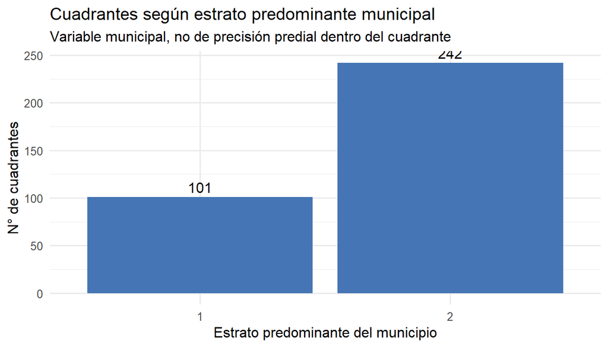

```r
cuadrantes_infra_estrato %>%
  st_drop_geometry() %>%
  filter(!is.na(estrato_predominante_municipal)) %>%
  count(estrato_predominante_municipal) %>%
  ggplot(aes(x = factor(estrato_predominante_municipal), y = n)) +
  geom_col(fill = "#4575b4") +
  geom_text(aes(label = n), vjust = -0.4) +
  labs(
    title    = "Cuadrantes según estrato predominante municipal",
    subtitle = "Variable municipal, no de precisión predial dentro del cuadrante",
    x = "Estrato predominante del municipio", y = "N° de cuadrantes"
  ) +
  theme_minimal(base_size = 12)
```

## Distribución por municipio (barras apiladas)

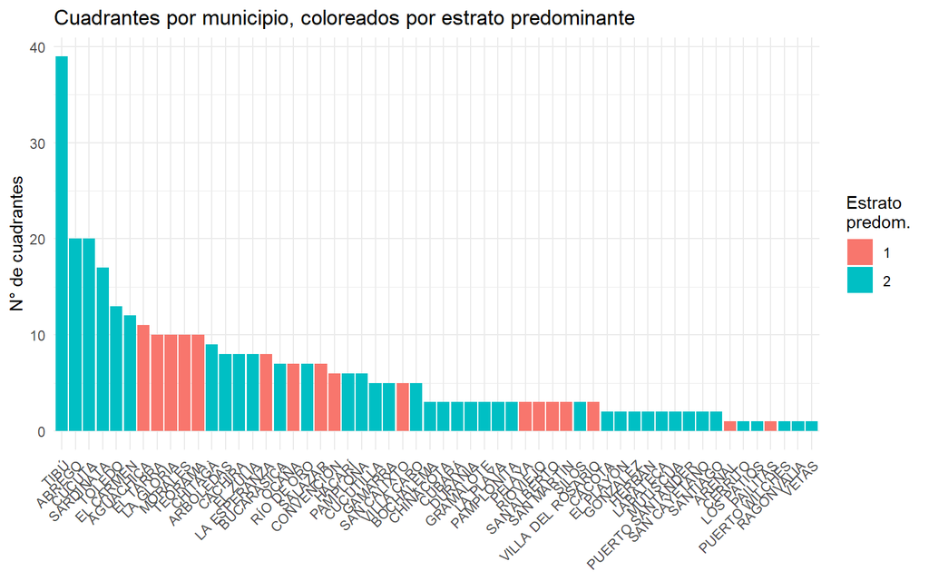

```r
cuadrantes_infra_estrato %>%
  st_drop_geometry() %>%
  filter(!is.na(municipio)) %>%
  count(municipio, estrato_predominante_municipal) %>%
  ggplot(aes(x = reorder(municipio, -n), y = n, fill = factor(estrato_predominante_municipal))) +
  geom_col() +
  labs(
    title = "Cuadrantes por municipio, coloreados por estrato predominante",
    x = NULL, y = "N° de cuadrantes",
    fill = "Estrato\npredom."
  ) +
  theme_minimal(base_size = 11) +
  theme(axis.text.x = element_text(angle = 45, hjust = 1))
```

## Mapa: estrato predominante municipal por cuadrante

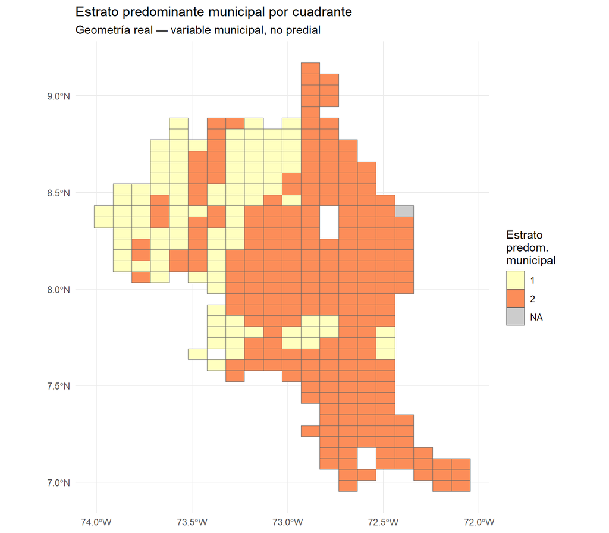

```r
ggplot(cuadrantes_infra_estrato) +
  geom_sf(aes(fill = factor(estrato_predominante_municipal)),
          color = "gray40", linewidth = 0.15) +
  scale_fill_brewer(palette = "RdYlBu", direction = -1,
                     na.value = "grey80", name = "Estrato\npredom.\nmunicipal") +
  labs(
    title    = "Estrato predominante municipal por cuadrante",
    subtitle = "Geometría real — variable municipal, no predial"
  ) +
  theme_minimal(base_size = 11)
```

## Mapa interactivo

```r
cuadrantes_wgs84 <- cuadrantes_infra_estrato %>% st_transform(4326)

pal_estrato_mun <- colorFactor(
  "RdYlBu",
  domain = cuadrantes_wgs84$estrato_predominante_municipal,
  reverse = TRUE,
  na.color = "grey80"
)

mapa_estrato <- leaflet(cuadrantes_wgs84) %>%
  addProviderTiles(providers$CartoDB.Positron) %>%
  addPolygons(
    fillColor = ~pal_estrato_mun(estrato_predominante_municipal),
    fillOpacity = 0.65, color = "gray40", weight = 0.6, opacity = 0.8,
    label = ~paste0(
      "Cuadrante ", id_cuadrante, " — ", municipio,
      ": estrato predom. municipal ", estrato_predominante_municipal
    )
  ) %>%
  addLegend(pal = pal_estrato_mun, values = ~estrato_predominante_municipal,
            title = "Estrato predom.\nmunicipal", position = "bottomright")

mapa_estrato
```

[interactive chart not shown]

# Parte 6 — Integración al panel y a la geometría exportada

## Actualizar la capa `cuadrantes_infra_reales` en el `.gpkg`

No se crea un archivo nuevo — se **actualiza** la capa existente dentro de `infraestructura_cuadrantes_reales.gpkg`, que a partir de aquí incluye también municipio, departamento, metodología de estratificación y estrato predominante municipal.

```r
st_write(
  cuadrantes_infra_estrato,
  ruta_gpkg_export,
  layer = "cuadrantes_infra_reales",
  delete_layer = TRUE
)
```

```
## Deleting layer `cuadrantes_infra_reales' using driver `GPKG'
## Writing layer `cuadrantes_infra_reales' to data source
##   `D:/OneDrive - PUJ Cali/Projecto_Grado_Javeriana/Data_Project//infraestructura_cuadrantes_reales.gpkg' using driver `GPKG'
## Writing 344 features with 36 fields and geometry type Multi Polygon.
```

```r
st_layers(ruta_gpkg_export)
```

```
## Driver: GPKG
## Available layers:
##                     layer_name geometry_type features fields crs_name
## 1               fallas_eventos         Point    47652      7   WGS 84
## 2 centroides_cuadrantes_reales         Point      344      3   WGS 84
## 3      cuadrantes_infra_reales Multi Polygon      344     36   WGS 84
```

## Incorporar al panel `data_final`

```r
estratificacion_cuadrante <- cuadrantes_infra_estrato %>%
  st_drop_geometry() %>%
  select(
    id_cuadrante, codigo_municipio, municipio,
    codigo_departamento, departamento,
    metodologia_estratificacion, n_estratos_municipio,
    estrato_predominante_municipal
  ) %>%
  distinct()

# Se descarta cualquier columna previa de estratificación municipal,
# para que correr el chunk más de una vez no genere duplicados .x/.y
data_final <- data_final %>%
  select(-any_of(names(estratificacion_cuadrante)[-1])) %>%
  left_join(estratificacion_cuadrante, by = "id_cuadrante")

cat(sprintf("Panel actualizado: %d filas x %d columnas\n",
            nrow(data_final), ncol(data_final)))
```

```
## Panel actualizado: 36120 filas x 75 columnas
```

### Cobertura de la integración

```r
cobertura_estrato <- data_final %>%
  summarise(
    filas_total                    = n(),
    filas_con_estrato               = sum(!is.na(estrato_predominante_municipal)),
    pct_cobertura                   = round(100 * mean(!is.na(estrato_predominante_municipal)), 2),
    cuadrantes_sin_estrato           = n_distinct(id_cuadrante[is.na(estrato_predominante_municipal)])
  )

kable(t(cobertura_estrato), col.names = "Valor",
      caption = "Cobertura de estratificación municipal en el panel") %>%
  kable_styling(bootstrap_options = c("striped"), full_width = FALSE)
```

Cobertura de estratificación municipal en el panel

|  | Valor |
| --- | --- |
| filas_total | 36120.00 |
| filas_con_estrato | 36015.00 |
| pct_cobertura | 99.71 |
| cuadrantes_sin_estrato | 1.00 |

# Parte 7 — Análisis exploratorio: estrato municipal y fallas

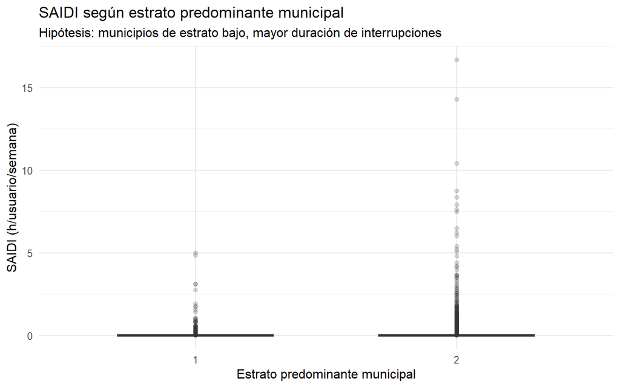

```r
if (all(c("SAIDI", "hubo_falla") %in% names(data_final))) {

  data_final %>%
    filter(hubo_falla == 1, !is.na(estrato_predominante_municipal)) %>%
    ggplot(aes(x = factor(estrato_predominante_municipal), y = SAIDI,
               fill = factor(estrato_predominante_municipal))) +
    geom_boxplot(outlier.alpha = 0.2, width = 0.6) +
    scale_fill_brewer(palette = "RdYlBu", direction = -1) +
    labs(
      title    = "SAIDI según estrato predominante municipal",
      subtitle = "Hipótesis: municipios de estrato bajo, mayor duración de interrupciones",
      x = "Estrato predominante municipal", y = "SAIDI (h/usuario/semana)"
    ) +
    theme_minimal(base_size = 12) +
    theme(legend.position = "none")

} else {
  message("SAIDI / hubo_falla no están en data_final: corre primero el pipeline de SAIDI/SAIFI.")
}
```

# Parte 8 — Guardado final del panel

```r
saveRDS(data_final, file.path(UBICACION_DATA, "data_final_modelo_cuadrantes_reales.rds"))
write_csv(data_final, file.path(UBICACION_DATA, "data_final_modelo_cuadrantes_reales.csv"))

cat(sprintf(
  "Panel final guardado: %d filas x %d columnas (incluye estratificación municipal)\n",
  nrow(data_final), ncol(data_final)
))
```

```
## Panel final guardado: 36120 filas x 75 columnas (incluye estratificación municipal)
```

## Exportación adicional: tabla de estratificación sola

```r
write_csv(
  estratificacion_cuadrante,
  file.path(UBICACION_DATA, "estratificacion_municipal_por_cuadrante.csv")
)
```

**Así se recarga esta información en otra sesión:**

```r
ruta_gpkg_export <- file.path(UBICACION_DATA, "infraestructura_cuadrantes_reales.gpkg")
st_layers(ruta_gpkg_export)

cuadrantes_infra_estrato <- st_read(ruta_gpkg_export, layer = "cuadrantes_infra_reales")

data_final <- readRDS(file.path(UBICACION_DATA, "data_final_modelo_cuadrantes_reales.rds"))

estratificacion_cuadrante <- read_csv(
  file.path(UBICACION_DATA, "estratificacion_municipal_por_cuadrante.csv")
)
```

# Diccionario de variables incorporadas

```r
tribble(
  ~Variable, ~Tipo, ~Variacion, ~Fuente, ~Descripcion,

  "codigo_municipio", "Categórica", "Cuadrante (estático)", "Estr_Capa.gdb",
    "Código DIVIPOLA del municipio donde se localiza el cuadrante (por intersección espacial o, en límites, por centroide).",

  "municipio", "Categórica", "Cuadrante (estático)", "Estr_Capa.gdb",
    "Nombre del municipio.",

  "metodologia_estratificacion", "Categórica", "Cuadrante (estático)", "Estr_Capa.gdb",
    "Tipo de metodología de estratificación aplicada por el municipio (urbana, rural, etc., según codificación oficial).",

  "n_estratos_municipio", "Numérica", "Cuadrante (estático)", "Estr_Capa.gdb",
    "Número de estratos socioeconómicos presentes en el municipio.",

  "estrato_predominante_municipal", "Categórica (1-6)", "Cuadrante (estático)", "Estr_Capa.gdb",
    "Estrato socioeconómico predominante del MUNICIPIO donde se localiza el cuadrante. No representa el estrato de las viviendas dentro del cuadrante — es una característica territorial municipal, no predial."
) %>%
  kable(caption = "Diccionario — variables de estratificación municipal") %>%
  kable_styling(bootstrap_options = c("striped", "hover", "condensed")) %>%
  column_spec(5, width = "42%")
```

Diccionario — variables de estratificación municipal

[output not shown]

**Recordatorio metodológico final:** con esta fuente se puede afirmar, por ejemplo, *“el X% de los cuadrantes se ubican en municipios cuyo estrato predominante es 2”* — pero **no** *“el X% de los cuadrantes son de estrato 2”*. La primera es la que los datos soportan. Además, `estrato_predominante_municipal` es, igual que `infra_cuadrante` y `estrato_modal` (cuando venía del shapefile catastral predial), **estática en el tiempo**: en un modelo con efectos fijos de cuadrante queda colineal con el efecto fijo y no se identifica en el estimador *within*. Es apropiada para modelos *pooled*/RE, caracterización territorial, o interacciones con variables temporales.